# Beginners Guide to Neural Networks & Deep Learning

###### An Introduction to Machine Learning by Md. Rishat Talukder

DO YOU WANT TO LEARN DEEP? DO YOU WANT TO KNOW HOW DEEP YOU CAN GO?

THEN YOU ARE IN THE RIGHT PLACE!

Neural Networks are the building blocks of Deep Learning. They are a the entry point to the world of Artificial Intelligence. Neural Networks are inspired by the human brain and are designed to simulate the way that humans learn but in a mathematical way. In this article, we will learn about the basics of Neural Networks, how they work, and how they are trained and how you can do it using Python.

For more article and content like this you can visit my:

- [LinkedIn](https://www.linkedin.com/in/md-rishat-talukder-a22157239/)
- [GitHub](https://github.com/RishatTalukder/learning_machine_learning/tree/main)
- [YouTube](https://www.youtube.com/channel/UCEEkKXpAkSwcMaIHnGi3Niw)

*** Pre-requisites:

- Basic understanding of Python
- Basic understanding of Mathematics
- Basic understanding of Machine Learning concepts and algorithms
- Basics of numpy, pandas, and matplotlib libraries

# Table of contents

- Introduction
- Part 1: Theory
  - Perceptron Model
    - Biological Neuron vs Perceptron
    - Perceptron
  - Neural Networks
  - Activation Functions
    - Sigmoid Activation Function
    - Tanh Activation Function
    - ReLU Activation Function
  - Multi-Class Classification
  - Cost Function Gradient Descent
    - Review of a Labeled Neural Network
    - Gradient Descent
      - Adaptive gradient descent
  - Backpropagation
    - Forward Pass
    - Backward Pass
- Neural Network With Python
  - Introduction
    - TensorFlow vs Keras
  - Installation and Syntax
    - Installation
    - Syntax
      - Training and Testing Data
    - Building the Neural Network
    - Evaluating the Neural Network
- Conclusion  
  - Happy Deep Learning

# Introduction

`Neural Networks` are a set of `algorithms`, `modeled loosely` after the `human brain`, that are designed to `recognize patterns`. They `interpret sensory data` through a kind of `machine perception`, `labeling`, or `clustering` of raw input. The patterns they recognize are `numerical` and contained in `vectors`, into which all real-world data (images, sound, text, etc.) must be `translated`.

`Neural Networks` help us `cluster` and `classify`. You can think of them as a `cluster of data` that can be trained to `recognize patterns`. They can be used to `model complex patterns` and `prediction problems` that are `non-linear` in nature.

# Part 1: Theory

## Perceptron Model

A `Perceptron` is a `single layer neural network` that helps in `classification` of data. It is a `linear classifier` and it is used in `supervised learning`. It helps to `classify the given input data`.

You can think of a `Perceptron` as a `single neuron` of a `Human Brain`. It takes `input`, processes it, and provides `output`.

If you think of a `Perceptron` as a `single neuron`, this is how it looks like:

```
graph LR
    A[Input] --> B[Processing Unit]
    B --> C[Output]
```

A `Perceptron` was a form of `neural network` introduced by `Frank Rosenblatt` in `1957`. It is the `simplest form` of a `neural network`.

Amazingly, even back almost `70 years ago`, `Frank Rosenblatt` was able to see the potential of `neural networks` and stated that...

> "The `Perceptron` may eventually be able to `learn`, `make decisions`, and `translate languages`."

Which is exactly what we are doing today with `Deep Learning` and `Neural Networks` and `Machine Learning` and `Artificial Intelligence` and in the base of all these, there is the `Perceptrons`.

And this is why it is important to understand the `Perceptron` model.

But it was not until the `1980s` that `Neural Networks` started to become popular again. Because in `1969`, `Marvin Minsky` and `Seymour Papert` published a book called `Perceptrons` which showed the `limitations` of `Perceptrons`. They showed that `Perceptrons` were `limited` to `linearly separable problems`. The book also suggested that `Perceptrons` were severely limited in what they could learn.

This Statement by `Marvin Minsky` and `Seymour Papert` led to the `first AI winter` where `funding` and `interest` in `Neural Networks` and `AI` `dried up`.

SO, back in the `1970s` There was not enough `computational power` to `train` `Neural Networks` and `Perceptrons` were `limited` to `linearly separable problems`.

But in the `1980s`, `Neural Networks` started to become popular again with the `discovery` of the `backpropagation algorithm` which allowed `Neural Networks` to learn `non-linear functions`.

### Biological Neuron vs Perceptron

A `Biological Neuron` is the `basic building block` of the `human brain`. It is a `cell` that helps in `transmitting information` to other `neurons` in the `brain`. It is made up of `Dendrites`, `Soma`, `Axon`, and `Synapse`. More simply, it takes `Denrites` as `input`, processes it in the `neucleus`, and provides `output` through `Axon` which is then transmitted to other `neurons` through `Synapse`.

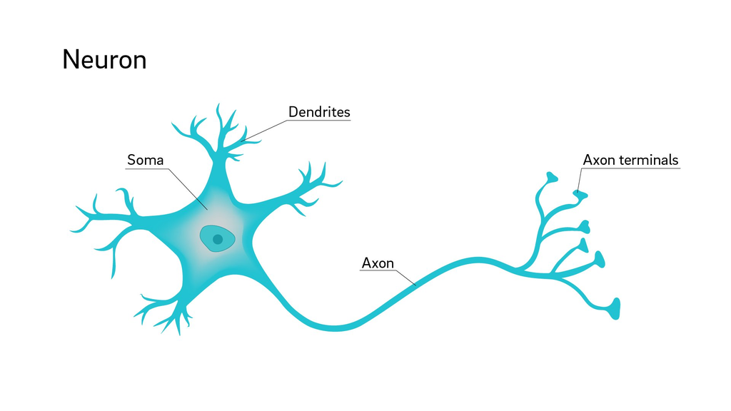

There are many more things in a single `Biological Neuron` but for the sake of simplicity, we will only discuss the basic things.

So, we have `dendrites` taking `input`, `nucleus` processing it, and `axon` providing `output`. This is literally whats happening inside our `brain`.

Now if I tell you to represent this `Biological Neuron` in a `mathematical way`, it will look like this:

```
graph LR
    A[Input] --> B[Processing Unit]
    B --> C[Output]
```

This is how a `Perceptron` works. It takes `input`, processes it, and provides `output`. It is a `mathematical model` of a `Biological Neuron`.

### Perceptron

Now again think of the `screen` you are looking at right now. It is made up of `pixels`. Each `pixel` has a `color` and `intensity`. If you think of a `pixel` as a `feature`, then a `Perceptron` can be used to `classify` the `pixel` as `black` or `white`. SO, by analyzing the the screen we can see, almost always, we are taking `multiple inputs` and `processing` them to get `output`.

SO, now suppose we have `two inputs` (X1, X2) and we want to `classify` them as `black` or `white` which we will represent as `y`. We can represent this as:

```
graph LR
    A[X1] --> B[Perceptron]
    C[X2] --> B
    B --> D[y]
```

Now, the `Perceptron` will take `input` from `X1` and `X2`, process it, and provide `output` as `y`.

We can represent the `Perceptron` as a `mathematical model` or a `function`. So, the final `perceptron` will look like this:

```
graph LR
    A[X1] --> B["Perceptron or f(x)"]
    C[X2] --> B
    B --> D[y]
```

So, now if I say that the `f(x)` is a `sum` then,

$$ y = x_1 + x_2 $$

Simple as that. This is the most simplistic form of a `Perceptron`. It takes `input`, `processes` it, and provides `output`.

Now Realistically, a we want to be able to adjust some `parameters` of the `Perceptron` to make it more `flexible` and `powerful`. In the above model there is no `flexibility` for the `Perceptron` to `learn` from the `data`. So, what we can do is add a `weight` to the `input` which will help the `Perceptron` to `learn` from the `data` more `efficiently`. SO, we will add the `weights` to the `input` as a `multiplication` factor. So, the `Perceptron` will look like this:

```
graph LR
    A[X1] --> |w1| B(("Perceptron or f(x)"))
    C[X2] --> |w2| B
    B --> D[y]
```

So, the `Perceptron` will take `input` from `X1` and `X2`, `multiply` it with `weights` `w1` and `w2`, `process` it, and provide `output` as `y`.

$$ y = w_1x_1 + w_2x_2 $$

So, now we can `adjust` the `weights` to make the `Perceptron` more `accurate` and select the `weights` that `minimize` the `error`. This will give us more `flexibility` to the `Perceptron` to `learn` from the `data`.

We can think of the `weights` as `parameters` of the `Perceptron` that we can `adjust` to make the `Perceptron` more `accurate`.

Now here's a brain teaser for you. What if the actual `input` is `X1` or `X2` is `0`? The `weights` will not have any effect on the `output`. How do we fix this?

The answer is to add a `bias` to the `Perceptron`.

> A `bias` is a constant that helps the `Perceptrons` input to have a `non-zero` value.

Bias is a `constant` That we can add to the input to make sure that the input is never `0`. So, the weights can have an effect on the output. We can represent the `bias` as `b`. And the `Perceptron` will look like this:

```
graph LR
    A[X1] --> |*w1+b| B(("Perceptron or f(x)"))
    C[X2] --> |*w2+b| B
    B --> D[y]
```

So, the `Perceptron` will take `input` from `X1` and `X2`, `multiply` it with `weights` `w1` and `w2`, `add` the `bias` `b`, `process` it, and provide `output` as `y`.

$$ y = (w_1x_1 + b) + (w_2x_2 + b) $$

So, now we can `adjust` the `weights` and `bias` to make the `Perceptrons` more `flexible` even with the `input` as `0`.

We can `generalize` the `Perceptron` as:

$$ y = w_1x_1 + w_2x_2 + b $$

Now think of `n` number of `inputs`. We can represent the `Perceptron` as:

```
graph LR
    A[X1] --> |*w1+b| B(("Perceptron or f(x)"))
    C[X2] --> |*w2+b| B
    D[Xn] --> |*wn+b| B
    B --> E[y]
```

Well, here's is the `mathematical model` of the `Perceptron` with `n` number of `inputs` and we can finally generalize the `Perceptron` as:

$$ y = w_1x_1 + w_2x_2 + ... + w_nx_n + b $$ $$ y = \sum_{i=1}^{n} w_ix_i + b $$

With this we can have modeled a `biological neuron` as a `simple perceptron`. Later in this article, we will see how we can `expand` the `input` be a `tensor` of information(n-dimensional array) and how we can `expand` the `Perceptron` to a `Neural Network`.

## Neural Networks

A `Neural Network` is a `set of algorithms`, `modeled loosely` after the `human brain`, that are designed to `recognize patterns`. They `interpret sensory data` through a kind of `machine perception`, `labeling`, or `clustering` of raw input. The patterns they recognize are `numerical` and contained in `vectors`, into which all real-world data (images, sound, text, etc.) must be `translated`.

> technical mumbo jumbo that you don't need to know

We have learned about the `Perceptron` model which is the `simplest form` of a `Neural Network`. A single `Perceptron` cannot learn cpmplecated patterns. But if we `stack` multiple `Perceptrons` together, we can create a `Neural Network` that can `learn` `complex patterns`.

A neural network is a `multi-layer perceptron` model that is designed to `recognize patterns` in the `data`.

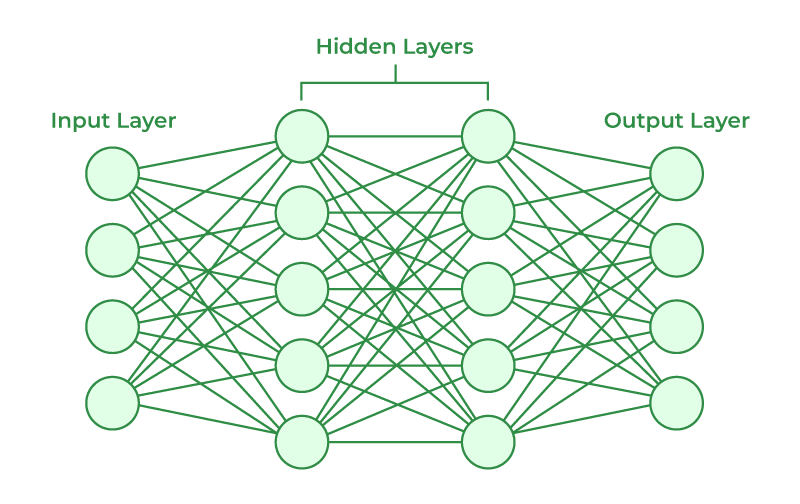

- The `first layer` is called the `input layer` and it takes the `input` from the `data`.
- The `middle layer` is called the `hidden layer` and it `processes` the `input` from the `input layer`.
- The `last layer` is called the `output layer` and it `provides` the `output` from the `hidden layer`.

Every `Perceptron` in a `layer` is `connected` to every `Perceptron` in the `next layer` and works as a `input` for the `next layer` and so on.

This `multi-layer perceptron` model is called a `Feedforward Neural Network` because the `input` is `fed forward` through the `network` and the `output` is `provided` at the `end`.

A `Neural Network` consists of `three layers`:

- `Input Layer`
- `Hidden Layer`
- `Output Layer`

> Input Layer: The `input layer` is the `first layer` of the `Neural Network`. It can have `n` number of `neurons/perceptrons` where `n` is the number of `features` in the `data`.

> Output Layer: The `output layer` is the `last layer` of the `Neural Network`. It can have `m` number of `neurons/perceptrons` where `m` is the number of `classes` in the `data` meaning the number of `output` we might have.

`Hidden Layer`: The `hidden layer` is the `middle layer` of the `Neural Network`. A hidden layer can have `n` number of `layers` and it's because of the `hidden layer` that the `Neural Network` can `learn` `complex patterns`. The `hidden layer` is the `magic` of the `Neural Network` where all the `processing` is done and the `patterns` are `learned`.

`Hidden layers` are hard to `interpret` and `understand` because they are `black boxes`. We don't know what is happening inside the `hidden layers` and how the `patterns` are `learned`. But we know that the `hidden layers` are the most `important` part of the `Neural Network`.

> Hidden layers have high connectivity and are distantly connected to the input and output layers.

> A `Neural Network` becames a `Deep Neural Network` when it has more than one `hidden layer`.

Previously, we have seen that a `Perceptron` can be represented as a `mathematical model` or a `function` like:

$$ y = w_1x_1 + w_2x_2 + ... + w_nx_n + b $$

But that would not be enough to for `classification` problems. We need to be able to add constraints to each `Perceptron` to get a useful `classification` output.

## Activation Functions

An `Activation Function` is a `function` that is added to the `Perceptron` to `introduce non-linearity` to the `output` of the `Perceptron`.

Let me simplify this for you.

Do you remember a single `perceptron` model. It takes `input X` which has `weights W` and `bias b` attached to it. Which means we have:

$$ y = wx + b $$

Here, The `W` clearly implies the weight of incoming `input`.

`b` is the `bias` value which is a constant value that helps the `Perceptrons` input to have a `non-zero` value. We can also think of the `bias` as a `offset` value that makes **xw** have to reach a certain threshold before it can have any effect on the output.

For example if `b=-10` in `x*w+b` then the effects of `x*w` won't really start to overcome the bias until `x*w` is greater than `10`.

After that, the effect will solely be determined by the value of `w` or the weight of the input.

That's why it's called a `bias` because it can `bias` the output of the `Perceptron` to be `positive` or `negative` depending on the value of the `bias`.

Now, the `output` of the `Perceptron` is `linear` in nature. It is a `straight line` and it can only `classify` `linearly separable` problems. But in the real world, we have `non-linear` problems that cannot be `classified` by a `linear` `Perceptron`.

So, we need to `introduce non-linearity` to the `output` of the `Perceptron` to `classify` `non-linear` problems. This is where the `Activation Functions` come in.

> To be completely dumb, you can say that `Activation Functions` are `functions` that are added to the `outputs` of the `Perceptrons` to transform the `output` into a `non-linear` form for `classification` of `non-linear` problems like `image classification`, `object detection`, `binary classification`, etc.

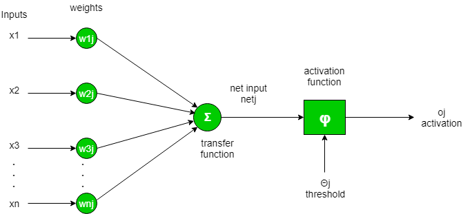

There are many `Activation Functions` that are used in `Neural Networks`. Some of the most popular `Activation Functions` are:

- `Sigmoid` (Logistic Function)
- `Tanh` (Hyperbolic Tangent)
- `ReLU` (Rectified Linear Unit)

### Sigmoid Activation Function

The `Sigmoid Activation Function` is a `non-linear` function that is used in `binary classification` problems. It is also called the `Logistic Function`.

The `Sigmoid Activation Function` is represented as:

$$ f(x) = \frac{1}{1 + e^{-x}} $$

The `Sigmoid Activation Function` takes the `output` of the `Perceptron` and `squashes` it between `0` and `1`. This is useful in `binary classification` problems where we need the `output` to be between `0` and `1`. You have done `logistic regression` before, right? It's the same thing.

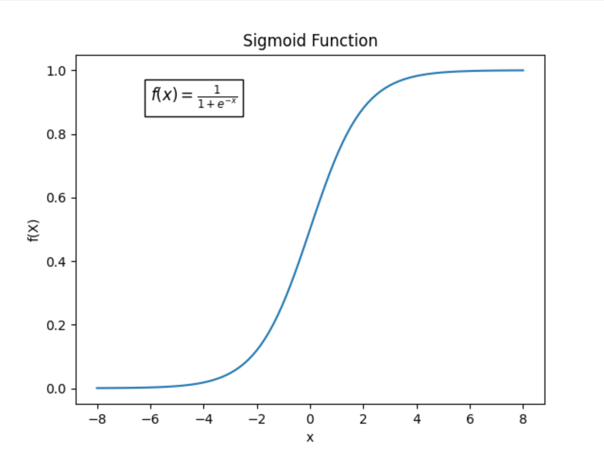

### Tanh Activation Function

The `Tanh Activation Function` is also a `non-linear` function that is used in `binary classification` problems. It is also called the `Hyperbolic Tangent`.

The `Tanh Activation Function` is represented as:

$$ f(x) = \frac{e^x - e^{-x}}{e^x + e^{-x}} $$

The `Tanh Activation Function` takes the `output` of the `Perceptron` and `squashes` it between `-1` and `1`. This is useful in `binary classification` problems where we need the `output` to be between `-1` and `1`.

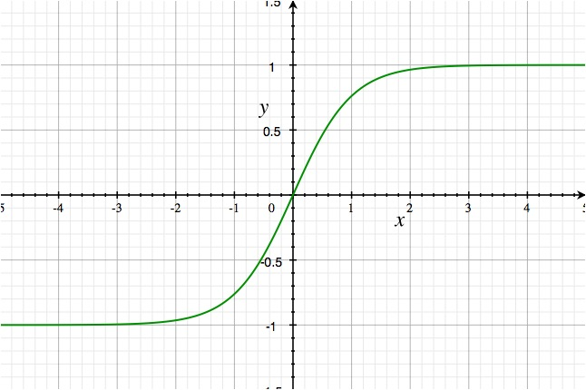

### ReLU Activation Function

One the most popular and widely used `Activation Function` is the `ReLU Activation Function`. `ReLU` stands for `Rectified Linear Unit`.

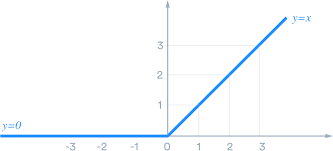

ReLU is a `linear` function that `returns` `0` if the `output` is `less than 0` and `returns` the `output` if the `output` is `greater than 0` as shown in the picture above.

The `ReLU Activation Function` is represented as:

$$ f(x) = max(0, x) $$

This function shows that the `output` will only be `0` if the `output` is `less than 0`.

The `ReLU Activation Function` is used in `Deep Neural Networks` because it is `computationally efficient` and it `speeds up` the `training` of the `Neural Network`. There have been many `improvements` to the `ReLU Activation Function` like the `Leaky ReLU` and the `Parametric ReLU` and there are still research going on to `improve` the `ReLU Activation Function`.

There are many more `Activation Functions` that are used in `Neural Networks`. But these are the most popular `Activation Functions` that are used in `Deep Neural Networks`.

You can visit the `wiki` page of `Activation Functions` to learn more about the `Activation Functions` that are used in `Neural Networks`. (https://en.wikipedia.org/wiki/Activation_function)

## Multi-Class Classification

This is a `classification` problem where we have `multiple classes` in the `data`. So, in the activation function, we saw how we can solve the problem of `binary classification` with the `Sigmoid`, `Tanh`, and `ReLU` activation functions. But what if we have `multiple classes` in the `data`?

It's farely simple if you think about it.

So, By multiple classes, I mean that we have `more than two classes` for a `classification` problem.

There can be two main types of `multi-class situations`:

- Non-Exclusive Classes
- Mutually Exclusive Classes

*** Non-Exclusive Classes

In `non-exclusive classes`, the `classes` are `not mutually exclusive`. This means that a `data point` can belong to `more than one class`. For example, a `data point` can be a `cat` and a `dog` at the same time or a `data point` can be a `car` and of `red color` at the same time.

*** Mutually Exclusive Classes

In `mutually exclusive classes`, the `classes` are `mutually exclusive`. This means that a `data point` can belong to `only one class`. For example, a `data point` can only be a `cat` or a `dog` but not both.

So, in `multi-class classification`, we need to have `multiple output neurons` in the `output layer` of the `Neural Network`. Each `output neuron` will represent a `class` in the `data`.

So, suppose we have `three classes` in the `target`, we must have `three output neurons` in the `output layer` of the `Neural Network`. Each `output neuron` will represent a `class` in the `data`.

So, if the `target class` has `n` number of `classes`, we must have `n` number of `output neurons` in the `output layer` of the `Neural Network`.

The `output` of the `Neural Network` will be a `vector` of `probabilities` where each `element` of the `vector` will represent the `probability` of the `data point` belonging to a `class`.

So, we cannot just have categories like `red`, `blue`, `green` in the `output layer`. We must have `probabilities` like `0.8`, `0.1`, `0.1` where `0.8` is the `probability` of the `data point` belonging to the `red` class and `0.1` is the `probability` of the `data point` belonging to the `blue` and `green` class.

So, in a `multi-class classification` problem, we can use the `one-hot encoding` technique to `encode` the `target` into a `vector` of `probabilities`.

If you don't know what `one-hot encoding` is, Here's a simple explanation:

`One-hot encoding` is a `technique` that is used to `convert` `categorical data` into a `numerical` `vector` of `0s` and `1s`. SO, duppose we have a dataset like this:

| data | target |
| --- | --- |
| 1 | red |
| 2 | blue |
| 3 | green |
| 4 | red |

We can `one-hot encode` the `target` like this:

| data | red | blue | green |
| --- | --- | --- | --- |
| 1 | 1 | 0 | 0 |
| 2 | 0 | 1 | 0 |
| 3 | 0 | 0 | 1 |
| 4 | 1 | 0 | 0 |

So, `one-hot encoding` breaks the `target` into `multiple columns` where each `column` represents a `class` in the `data` then `encodes` the `target` into a `vector` of `0s` and `1s`.

Now, we have the data `organized` and `ready` for `multi-class classification`. Now, all we have to do is set up the right `activation function` for the output layers.

For `non-exclusive classes`, we can use the `Sigmoid` activation function in the `output layer`.

As I have talked about the `Sigmoid` activation function before, it `squashes` the `output` between `0` and `1` and gives us the `probability` of the `data point` belonging to a `class` in between `0` and `1`.

SO, we can just choose the `class` with the `highest probability` as the `predicted class`.

For `mutually exclusive classes`, we can use a cleaver `activation function` called the `Softmax` activation function in the `output layer`.

The `Softmax` activation function is a `generalization` of the `Sigmoid` activation function. It also `squashes` the `output` between `0` and `1` but it also `normalizes` the `output` to `sum` to `1`. What does this mean?

Suppose we have a `data point` that can belong to `three classes` like `red`, `blue`, and `green`. If we use `sigmoid` activation function, let say the output is `[0.8, 0.3, 0.1]`. We can clearly see that the first `class` has the `highest probability` of the `data point` belonging to the `red` class. But here's the catch, the `output` is not `normalized`, you can get the `output` like `[0.8, 0.8, 0.8]` which is not `normalized` and it's not good for `classification`.

So, the `Softmax` activation function `normalizes` the `output` to `sum` to `1`. This means that whatever happens, the `output` will always `sum` to `1`. So, the `output` will be `[0.5, 0.3, 0.2]` which is `normalized` and it's good for `classification`.

`Softmax` activation function is used in `multi-class classification` problems where the `classes` are `mutually exclusive`. It is represented as:

$$ f(x) = \frac{e^{x_i}}{\sum_{j=1}^{n} e^{x_j}} $$

Here, `n` is the number of `classes` in the `data` and you can see that the `j` is the `index` of the `classes` in the `data`.

So, this gives us a `normalized` `output` because the `output` will always `sum` to `1` .

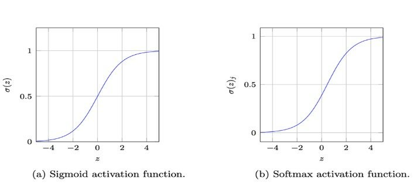

> time to learn about the `cost function` and `backpropagation`

## Cost Function Gradient Descent

`Cost function` is by far the most important and interesting part of the `Neural Network`.

Until now we have learned that a `Neural Network` is a `set of neurons` that are `connected` to each other.

There can be multiple layers. The `first layer` is the `input layer` which takes:

- the inputs->multiplies them with the `weights`->adds the `bias`->passes it to the
- `hidden layer`->the `hidden layer` processes the `input`->passes it to the
- `output layer`->the `output layer` provides the `output` which is then passed to the
- `activation function` to `squash` the `output` between `0` and `1` or `-1` and `1` to predict the `class`.

But how do we know that the `output` is `correct`? How do we know that the `Neural Network` is `learning` from the `data`? How do we know that the `Neural Network` is `accurate`? Also how can we update the `weights` and `bias` to make the `Neural Network` more `accurate`?

How can we update the `weights` and `bias` is a part of the `backpropagation` algorithm which we will learn later in this article. But first let's answer the other questions.

The `Cost function` is a `function` that is used to `evaluate` the `performance` of the `Neural Network`. It `measures` the `difference` between the `predicted output` and the `actual output` of the `Neural Network`.

The `Cost function` is also called the `Loss function` or the `Error function`. It is a `function` that is used to `minimize` the `error` of the `Neural Network`.

Basically it `measures` how far off the `predicted output` is from the `actual output`. The `goal` of the `Neural Network` is to `minimize` the `cost function` to make the `Neural Network` more `accurate`.

> A cost function must provide an average of the loss of the entire dataset so that it can return a single scalar value. We can also keep track of the loss/cost during the training process to see how the model is learning.

There are many `Cost functions` that are used in `Neural Networks`. Some of the most popular `Cost functions` are:

- `Mean Squared Error` (MSE)
- `Cross-Entropy Loss`

We will discuss about these later in this article.

BTW, THERE WILL BE MASSIVE MATHS IN THIS SECTION. SO, READY YOUR BRAIN CELLs TO NOT UNDERSTAND SHIT.(just kidding)

So, let's talk about the new variables.

- `y` would be the actual class
- `a` will be the predicted class.

> As you remember I used `y` for the perceptron model.

And in terms of `weights` and `biases`:

- z = w*x + b
- we will pass `z` instead of `y`(because y is denoted as actual/true class)into the activation function `σ(z) = a` (sigma of z = predicted class/value)

We can think of `cost function` as as a function of 4 main things:

$$ C(W,B,S^r,E^r) $$

- W is for Weights
- B is for Biases
- S<sup>r</sup> is The input of a single training sample.
- E<sup>r</sup> is the desired output.

Now we can talk about our first `cost function`.

*** Quadratic Cost Function or Mean Squared Erre(MSE)

The `quadratic cost function`, also known as the `mean squared error (MSE)`, is one of the commonly used `cost functions` in `neural networks`. It measures the average squared difference between the `predicted output` and the `actual output`.

Mathematically, the `quadratic cost function` is defined as:

$$ C = \frac{1}{2n} \sum_{i=1}^{n} (y_i - a_i)^2 $$

Here, `C` represents the `cost`, `n` is the number of `training examples`, `y_i` is the `actual output` for the i-th `training example`, and `a_i` is the `predicted output` for the i-th `training example`.

Why are we `squaring` the difference between the actual and predicted output?

The `quadratic cost function` penalizes larger errors more heavily due to the `squaring operation`. It aims to minimize the overall squared difference between the `predicted` and `actual outputs`, making it suitable for `regression problems`.

> Sometimes there will be some values that are going to be way off the actual value. So, we need to penalize them more heavily. This is why we square the difference between the actual and predicted output.

During the `training process`, the `neural network` adjusts its `weights and biases` using `gradient descent` to minimize the `quadratic cost function`. By iteratively updating the `weights and biases`, the `neural network` learns to make more accurate predictions.

Although the `quadratic cost function` is widely used, it may not be suitable for all types of problems. In some cases, such as `classification problems` with `mutually exclusive classes`, other `cost functions` like `cross-entropy loss` are preferred.

*** Cross-Entropy Loss

The `cross-entropy loss`, also known as `log loss`, is another commonly used `cost function` in `neural networks`. It is particularly well-suited for `classification problems` with `mutually exclusive classes`.

Mathematically, the `cross-entropy loss` is defined as:

$$ C = -\frac{1}{n} \sum_{i=1}^{n} [y_i \log(a_i) + (1 - y_i) \log(1 - a_i)] $$

FOR M Number of classes:

$$ C = -\sum_{j=1}^{M} y_{ij} \log(a_{ij}) $$

Here, `C` represents the `cost`, `n` is the number of `training examples`, `y_i` is the `actual output` for the i-th `training example`, and `a_i` is the `predicted output` for the i-th `training example`.

The `cross-entropy loss` penalizes the `predicted output` based on how well it matches the `actual output`. It aims to minimize the difference between the `predicted` and `actual outputs`, making it suitable for `classification problems`.

During the `training process`, the `neural network` adjusts its `weights and biases` using `gradient descent` to minimize the `cross-entropy loss`. By iteratively updating the `weights and biases`, the `neural network` learns to make more accurate predictions.

The choice of `cost function` depends on the `nature of the problem` and the `type of output` the `neural network` is expected to produce. By selecting an appropriate `cost function`, the `neural network` can be trained to make accurate predictions for a wide range of applications.

`NOOOOOW, THINGS ARE GOING TO GET MORE COMPLICATED FROM HERE`

### Review of a Labeled Neural Network

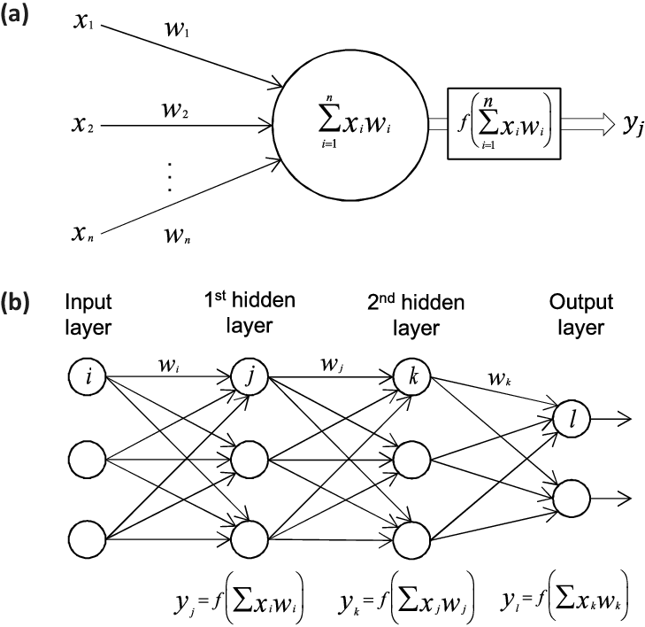

This is one of the simplest neural networks that you can have. But still looks compelcated.

And we have to calculated all of this to get a single `predicted value`.

In real cases, we have `thousands` of `neurons` and `millions` of `weights` and `biases` to `learn` from the `data`. So, this means we have some `cost function` to `minimize` to make the `Neural Network` more `accurate` and that cost function is heavily dependent on those thousands of `weights`.

So, do we figure out which weights leads to the lowest cost function?

First let's imagine our cost function is dependent on a single weight `w` and we want to minimize it. So, we need to figure out which value of `w` leads to the lowest cost function.

If we plot out the cost function with respect to `w`, it will look like this:

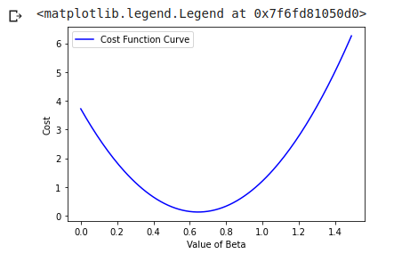

Now if you look closly, you will see how we can really minimize the cost function. The curve is `convex` and the `minimum` is at the `bottom` of the curve. So, if we take the closest point to the `bottom` of the curve, that will be our best `w` to minimize the cost function.

BUT, There is always a big Butt.

The `cost function` is not dependent on a single `weight`. It is dependent on `thousands` of `weights` and `biases`. Which means this curve is not a `2D` curve but a `n-dimensional` curve. So, we cannot just plot out the `cost function` and find the `minimum` value of the `weights` to minimize the `cost function` but we have to take every weight in consideration to minimize the `cost function`.

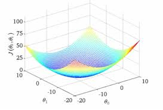

Since we cannot plot out the `cost function` to find the `minimum` value of the `weights`, we have to use a `mathematical` `algorithm` to `minimize` the `cost function`. This is where the `Gradient Descent` algorithm comes in.

### Gradient Descent

`Gradient Descent` is a `mathematical` `algorithm` that is used to `minimize` the `cost function` of the `Neural Network`. It is an `iterative` `optimization` `algorithm` that `updates` the `weights` and `biases` of the `Neural Network` to `minimize` the `cost function`.

SO, if we go back to that `2D` curve, we can start from any point on the curve and `descend` to the `bottom` of the curve to find the `minimum` value. How do we do that?

You should know some calculus to understand this better.

- We can calculate the `slope` of the `curve` at a `point` on the `curve`. The `slope` of the `curve` at a `point` is the `derivative` of the `curve` at that `point`. The `derivative` of the `curve` at a `point` tells us the `direction` in which the `curve` is `increasing` or `decreasing`.
- If the `slope` is `positive`, we move `left` to `descend` to the `bottom` of the curve.
- If the `slope` is `negative`, we move `right` to `descend` to the `bottom` of the curve.
- This repeats untill eventually the `slope` is `0` and we have reached the `bottom` of the curve.

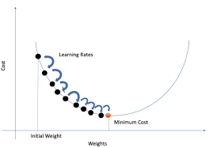

Now if you paid attention you would have figured out that we are at the `bottom` of the curve and while doing so we also `update` the `weights` and `biases` of the `Neural Network`, So the updated `weights` and `biases` will be the `minimum` value of the `cost function`.

Now, here's a question for you to think about. We started from random `point` on the `curve` and `descended` to the `bottom` of the curve. But how do we choose the next `point` to `descend` to the `bottom` of the curve?

The answer is `learning rate`.

`Learning rate` is a `hyperparameter` that is used to `control` the `step size` of the `gradient descent` `algorithm`.

> steps size refers to the `distance` we move to `descend` to the `bottom` of the curve.

If the `learning rate` is `small`, we take `small steps` to `descend` to the `bottom` of the curve. Which takes a lot of time to `converge` to the `minimum` value of the `cost function` but the right `minimum` value of the `cost function` is `guaranteed`.

If the `learning rate` is `large`, we take `large steps` to `descend` to the `bottom` of the curve. Which takes less time to `converge` to the `minimum` value of the `cost function` but this might lead to `overshooting` the `minimum` value of the `cost function`. So, we might not get the right `minimum` value of the `cost function`.

So, the `learning rate` is a `hyperparameter` that is used to `control` the `step size` of the `gradient descent` `algorithm`. It is `tuned` to get the right `minimum` value of the `cost function`.

#### Adaptive gradient descent

`Adaptive gradient descent` is a `variant` of the `gradient descent` `algorithm` that `adapts` the `learning rate` during the `training process`. It `adjusts` the `learning rate` based on the `gradient` of the `cost function` at each `iteration`.

In the discussion above, we talked about the `fixed learning rate` that is `manually set` before the `training process`. So, the `fixed learning rate` is `constant` throughout the `training process`.

But what we can do is `adapt` the `learning rate` based on the `gradient` of the `cost function` at each `iteration`. This is called `adaptive gradient descent`.

We can start with larger `learning rate` and `slowly decrease` the `learning rate` as we the `gradient` of the `cost function` `decreases` and gets closer to `0`. This will help us to `converge` to the `minimum` value of the `cost function` more `efficiently` and `quickly`.

There are many `adaptive gradient descent` `algorithms` that are used in `Neural Networks`. Some of the most popular `adaptive gradient descent` `algorithms` are:

- `Adagrad` (Adaptive Gradient Algorithm)
- `RMSprop` (Root Mean Square Propagation)
- `ADAM` (Adaptive Moment Estimation)
  - In 2015, Kingma and Ba introduced the `ADAM` `algorithm` which is an `adaptive` `gradient descent` `algorithm` that `adapts` the `learning rate` based on the `first` and `second moments` of the `gradients`.
  - The `ADAM` `algorithm` `combines` the `advantages` of `Adagrad` and `RMSprop` `algorithms` and `performs` well on a wide range of `Neural Networks`.

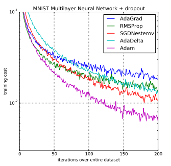

We will use the `ADAM` `algorithm` in our `Neural Network` implementation.

So, we while finding the `minimum` value of the `cost function`, we are actually finding the `descent` in a n-dimensional curve for all the `weights`. And as we are dealing with these n-dimensional curves, the notations change from `slope` to `gradient`.

This means we calculate,

$$ \nabla C = \frac{\partial C}{\partial w} $$

That's it for the `Cost function` and `Gradient Descent` section.

> Too many concepts right?

Now time to finish the Theory part of the `Neural Network` by learning about the `Backpropagation` algorithm.

## Backpropagation

`Backpropagation` is a very `mathemetically` `intensive` `algorithm` that is used to `train` the `Neural Network`.

If you thoght that `Gradient Descent` was `complicated`, `Backpropagation` is `more complicated` than that with heavy `derivative` and `chain rule` calculations.

I genuinely don't want to go through the `maths` of the `Backpropagation` algorithm because it's `too complicated` and `hard to understand`. But I will try to explain the `Backpropagation` algorithm in a `simple` and `easy` way.

So, let's start with the `Forward Pass`.

### Forward Pass

The `Forward Pass` is the `first step` in the `Backpropagation` `algorithm`. It is the `process` of `feeding` the `input` through the `Neural Network` to `generate` the `output`.

During the `Forward Pass`, the `input` is `fed` through the `input layer` and `propagated` through the `hidden layers` to `generate` the `output` from the `output layer`.

The `output` from the `output layer` is `compared` with the `actual output` to `calculate` the `cost function`. The `cost function` is a `measure` of how `well` the `Neural Network` is `performing`.

The `cost function` is then `used` to `update` the `weights` and `biases` of the `Neural Network` during the `Backward Pass`.

### Backward Pass

The `Backward Pass` is the `second step` in the `Backpropagation` `algorithm`. It is the `process` of `updating` the `weights` and `biases` of the `Neural Network` to `minimize` the `cost function`.

During the `Backward Pass`, the `gradient` of the `cost function` with respect to the `weights` and `biases` is `calculated` using the `chain rule` of `calculus`.

The `chain rule` of `calculus` is used to `calculate` the `partial derivatives` of the `cost function` with respect to the `weights` and `biases` of the `Neural Network`.

The `partial derivatives` are then `used` to `update` the `weights` and `biases` of the `Neural Network` using the `gradient descent` `algorithm`.

The `weights` and `biases` are `updated` in the `opposite direction` of the `gradient` of the `cost function` to `minimize` the `cost function`.

The `Backward Pass` is `repeated` for `multiple iterations` until the `cost function` is `minimized` and the `Neural Network` is `trained` to make `accurate predictions`.

I know this is not enough to even visualize the `Backpropagation` algorithm but I not crazy enough to type out the `maths` in latex for you to just `read` and `forget` and I know for a fact that you are not going to `understand` by just `reading` the `maths` without any `visual` `representation` of why we are doing this.( it tool me 3 hour to just get the gist of it)

So, i will share some links where you can learn and find example of the `Backpropagation` algorithm.

MATH:

- [Backpropagation Algorithm(WIKIPEDIA)](https://en.wikipedia.org/wiki/Backpropagation)

VIDEO:

- [Whats really happening in Backpropagation(Channel: 3Blue1Brown)](https://www.youtube.com/watch?v=Ilg3gGewQ5U)
- [Backpropagation Calculus(Channel: 3Blue1Brown)](https://www.youtube.com/watch?v=tIeHLnjs5U8)
- [Neural Networks Playlist(Channel: 3Blue1Brown)](https://www.youtube.com/watch?v=aircAruvnKk&list=PLZHQObOWTQDNU6R1_67000Dx_ZCJB-3pi)
- [Neural networks from scratch](https://www.youtube.com/watch?v=w8yWXqWQYmU&t=519s)

So, that's it for the `Backpropagation` algorithm. I hope you have learned something new and interesting about the `Neural Network`.

Now, let's move on to the `Neural Network` implementation in `Python` using the `Keras` library.

# Neural Network With Python

## Introduction

In this section, we will implement a `Neural Network` in `Python` using the `TensorFlow` and `Keras` libraries. These two are the most popular libraries for `Deep Learning` and `Neural Networks`.

But Why two libraries?

### TensorFlow vs Keras

| TensorFlow | Keras |
| --- | --- |
| TensorFlow is an `open-source` `machine learning` `library` developed by `Google`. | Keras is an `open-source` `neural network` `library` written in `Python`. |
| TensorFlow is a `low-level` `library` that provides `flexibility` and `control` over the `neural network` `architecture`. | Keras is a `high-level` `library` that provides a `simple` and `intuitive` `interface` for `building` and `training` `neural networks`. |
| TensorFlow is `widely used` for `research` and `production` `applications`. | Keras is `popular` for `quick` `prototyping` and `experimentation`. |
| TensorFlow 1.x required `more boilerplate code` to `build` and `train` `neural networks`. | Keras provides a `simple` and `intuitive` `API` for `building` and `training` `neural networks`. |
| TensorFlow 2.x `integrates` the `Keras API` as its `default` `high-level` `API`. | Keras is `integrated` into `TensorFlow 2.x` as its `default` `high-level` `API` because of it's ease of use and simplicity. |
| TensorFlow provides `low-level` `APIs` for `customization` and `control` over the `neural network` `architecture`. | Keras provides a `high-level` `API` for `quick` `prototyping` and `experimentation`. |
| TensorFlow has `support` for `distributed computing` and `deployment` on `multiple platforms and languages`. | Keras is `easy to learn` and `use` for `building` and `training` `neural networks` but it is `less flexible` than `TensorFlow`. |

In simple words, `Keras` is easy to use and `TensorFlow` is more `flexible` and `powerful`. But in `TensorFlow 2.x`, `Keras` is `integrated` as the `default` `high-level` `API` for `building` and `training` `neural networks`, so you can use `Keras` with `TensorFlow` to `build` and `train` `neural networks` without the need to `install` `Keras` separately.

SO, As we are going to use `TensorFlow and Keras` to `build` and `train` the `Neural Network`, we will use only `TensorFlow` library and we will `import` the `Keras` `API` from `TensorFlow` to `build` and `train` the `Neural Network`.

So, Let's get started.

## Installation and Syntax

### Installation

It's easy to `install` the `TensorFlow` library using the `pip` `package manager` or `conda` `package manager`.

You can get more information about the `installation` of `TensorFlow` from the `official` `TensorFlow` `website`. (https://www.tensorflow.org/install/pip)

Here's how you can `install` the `TensorFlow` library using the `pip` `package manager`:

```
#terminal
python -m pip install tensorflow

#jupyter notebook cell
!pip install tensorflow
```

In `conda` `package manager`, you can `install` the `TensorFlow` library using the following command:

```
# teminal
conda install tensorflow

#jupyter notebook cell
!conda install tensorflow
```

This will install the `TensorFlow` library that will use your `CPU` to `build` and `train` the `Neural Network`. If you have a `GPU`, you can `install` the `TensorFlow-GPU` library that will use your `GPU` to `build` and `train` the `Neural Network`.

You can get more information about the `installation` of `TensorFlow-GPU` from the `official` `TensorFlow` `website`. (https://www.tensorflow.org/install/gpu)

> I installed the `CPU` version of the `TensorFlow` library because I don't have a `nvivida` `GPU` to `install` the `TensorFlow-GPU` library.

> To install using `jupyter notebook` cell, you need to add `!` before the command then run the cell. the cell cannot be run in `markdown` mode.

```python
#!pip install tensorflow
```

Now that we have `installed` the `TensorFlow` library, let's `import` the `TensorFlow` library and test if it is `installed` correctly.

```python
import tensorflow as tf

print(tf.__version__)
```

```
2.15.0
```

Noice.

We have installed `tensorflow 2.15.0`. Now let's test if the `tensorflow` library is `installed` correctly.

Copy and paste the code below. If it returns a `tensor`. Then the `tensorflow` library is `installed` correctly.

```python
tf.reduce_sum(tf.random.normal([1000, 1000]))
```

```
<tf.Tensor: shape=(), dtype=float32, numpy=-2411.045>
```

Alright now we have everything set up. Let's start building. I'll have all the datasets I use in my github repository linked at the `beginning` of the notebook.

Let's learn some `syntax` of the `tensorflow` library.

### Syntax

> The syntax will be heavy on `keras` because it is `integrated` into `tensorflow 2.x` as the `default` `high-level` `API` for `building` and `training` `neural networks` and it's easy.

The `TensorFlow` library provides a `simple` and `intuitive` `API` for `building` and `training` `neural networks`. Before starting to use the `TensorFlow` library, we need some `data`.

> Every dataset is available in my github repo. There other dataset which you can use and experiment with.

Let's import the data.

```python
import numpy as np
import pandas as pd

df = pd.read_csv("TensorFlow_FILES/DATA/fake_reg.csv")
df.head()
```

|  | price | feature1 | feature2 |
| --- | --- | --- | --- |
| 0 | 461.527929 | 999.787558 | 999.766096 |
| 1 | 548.130011 | 998.861615 | 1001.042403 |
| 2 | 410.297162 | 1000.070267 | 998.844015 |
| 3 | 540.382220 | 999.952251 | 1000.440940 |
| 4 | 546.024553 | 1000.446011 | 1000.338531 |

This is a `fake_dataset` where you are given prices according to the `features`. SO, you can see that the dataset has `three` `features`, `feature1`, `feature2`, and `price`. The `price` is the `target` that we need to `predict` using the `features`.

We can do some visualizations to understand the `data` better.

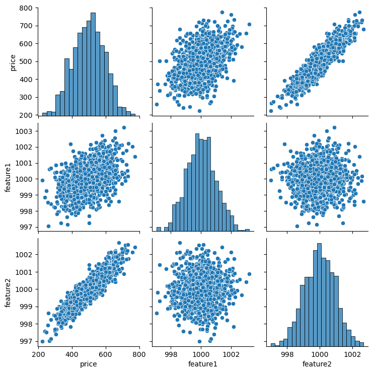

```python
import seaborn as sns

sns.pairplot(df)
```

We can see that `feature2` has very high `correlation` with the `price` and `feature1` has very low `correlation` with the `price`. This is another indicator that this is a `fake dataset`.

So, before going into more details, We need to know the workflow of building a `Neural Network` in `TensorFlow and Keras`.

#### Training and Testing Data

The next step is to `split` the `data` into `training` and `testing` `data`. This is because we need to `train` the `Neural Network` on the `training data` and `test` the `Neural Network` on the `testing data`.

We can do this by using the `train_test_split` `function` from the `sklearn` `library`.

```python
from sklearn.model_selection import train_test_split
```

Now we have to make two different `dataframes`, one is the `features` and the other is the `target` and the `features`, `target` has to be `numpy arrays` to `feed` it to the `Neural Network`. it's because the `Neural Network` only `understands` `numpy arrays`.

> if you have done this in the machine learning algorithms or projects then you know what I am talking about. The only difference is we cannot train the `Neural Network` on `dataframes` but we can train the `Neural Network` on `numpy arrays`.

```python
# Features
X = df[['feature1', 'feature2']].values # .values converts to numpy array
```

```python
y = df[['price']].values
```

Now we have two `numpy arrays`, You can see the proof of the `numpy arrays` by using the `type` `function`.

```python
print(f"features data X is: {type(X)}")
print(f"target data y is: {type(y)}")
```

```
features data X is: <class 'numpy.ndarray'>
target data y is: <class 'numpy.ndarray'>
```

There you go, we have two `numpy arrays` that we can `feed` to the `Neural Network`. Now let's split the `data` into `training` and `testing` `data`.

`train_test_split` `function` will `split` the `data` into `training` and `testing` `data` and return `four` `numpy arrays`, `X_train`, `X_test`, `y_train`, and `y_test`.

We can also pass the `test_size` `parameter` to `train_test_split` `function` to `specify` the `percentage` of the `data` that we want to `split` into `testing` `data`. The `default` `value` of the `test_size` `parameter` is `0.25` which means `25%` of the `data` will be `split` into `testing` `data`.

```python
X_train, X_test, y_train, y_test = train_test_split(X, y, test_size=0.3) # 30% of data will be test data
```

Now we have a `training` and `testing` `data` with `70/30` `split`. We can see the `shape` of the `training` and `testing` `data` using the `shape` `attribute`.

```python
X_train.shape
```

```
(700, 2)
```

```python
X_test.shape
```

```
(300, 2)
```

Well. we can clearly see that the `training` `data` has `700` `samples` and the `testing` `data` has `300` `samples`. The `features` have `two` `columns` and the `target` has `one` `column`.

Now that we have split the data. It's time for `Normalization`. There are many ways to `normalize` the `data`. But the most common way is to use the `MinMaxScaler` `function` from the `sklearn` `library`.

This will `normalize` the `data` between `0` and `1`. This is because the `Neural Network` `performs` `better` when the `data` is `normalized` between `0` and `1`.

```python
from sklearn.preprocessing import MinMaxScaler

scaler = MinMaxScaler()
scaler.fit(X_train)
```

```
MinMaxScaler()
```

We have made a `MinMaxScaler` `object` and `fitted` it to the `training` `data`. This will `normalize` the `training` `data` between `0` and `1`. Now we transform the `training` and `testing` `data` using the `transform` `method`.

```python
X_train = scaler.transform(X_train)
```

```python
X_test = scaler.transform(X_test)
```

As, I said before after transforming the the max value of the `features` will be `1` and the min value will be `0`. Let's check if it's `normalized` or not.

```python
X_train.max()
```

```
1.0
```

```python
X_train.min()
```

```
0.0
```

We have successfully `normalized` the `data` between `0` and `1`. Now we can `feed` this `normalized` `data` to the `Neural Network`.

Now Time to make the `Neural Network`.

### Building the Neural Network

The `Neural Network` is `built` using the `Sequential` `class` from the `Keras` `API` of the `TensorFlow` `library`. The `Sequential` `class` is used to `build` a `sequential` `model` of the `Neural Network`.

And we also need the `Dense` `class` from the `Keras` `API` to `build` the `layers` of the `Neural Network`. The `Dense` `class` is used to `build` the `fully connected` `layers` of the `Neural Network`.

So, we need import the `Sequential` and `Dense` `classes` from the `Keras` `API` of the `TensorFlow` `library`.

> I know that was hard to understand but I will explain it in a `simple` way after importing the `Sequential` and `Dense` `classes`.

```python
from tensorflow.keras.models import Sequential
from tensorflow.keras.layers import Dense
```

The `sequential` `model` is equivalent to the `perceptron model` that we have `learned` before in the `theory` section. The `sequential` `model` is a `linear stack` of `layers` where each `layer` has `neurons` that are `connected` to the `neurons` in the `previous` and `next` `layers`.

The `Dense` `class` is used to `build` the `fully connected` `layers` of the `Neural Network`. The `Dense` `class` has `three` `parameters` that are `required` to `build` the `fully connected` `layers` of the `Neural Network`.

- `units`: The `number` of `neurons` in the `layer`.
- `activation`: The `activation function` that is `applied` to the `output` of the `neurons`.
- `input_shape`: The `shape` of the `input` to the `layer`.

SO, To be `simple`, we actually have everything we need to `build` a `simple` `Neural Network`. We have the `Sequential` `class` to `build` the `perceptron model` and the `Dense` `class` to `build` the `fully connected layers` of the `Neural Network`.

And it's all because of the `Keras` `API` that is `integrated` into the `TensorFlow` `library`. If you want to learn more about the `classes` we just imported you can run the `help` `function` on the `classes`.

```python
# help(Sequential)
# help(Dense)
```

This will show you all the different ways you can use this class with other `parameters` and `attributes`.

> I commented out because it's too long to show here in this article.

SO, let's make the `Neural Network`.

First we make a `sequential model` using the `Sequential` `class`.

```python
model = Sequential()
```

Then we `add` the `layers` to the `Neural Network` using the `add` `method`. We `add` the `layers of neurons` to the `model` using the `Dense` `class`.

```python
model.add(Dense(4, activation='relu'))
```

```python
model.add(Dense(4, activation='relu'))
model.add(Dense(4, activation='relu'))
```

This is the `hidden layer`, it has `4` `neurons` and the `activation function` is `relu`. This is the `layer` that `processes` the `input` and `passes` it to the `next layer`.

```python
model.add(Dense(1))
```

This is the `output layer`, it has only `1` `neuron` and the `activation function` is set to the `default` `activation function` which is `linear`. It is set to linear because we are `predicting` a `continuous` `value` of price and it's not categorical. If it was categorical, we would have used `softmax` `activation function`.

We can also so the same by passing a `list` of `layers` to the `Sequential` `class` to `build` the `Neural Network` like this.

```
model = Sequential([
    Dense(units=4, activation='relu'), # input layer
    Dense(units=4, activation='relu'), # hidden layer
    dense(units=4, activation='relu'), # hidden layer
    Dense(units=1) # output layer
])
```

But this is a little bit `hard` to `read` and `understand`. So, we use the `add` `method` to `add` the `layers` to the `Neural Network`.

Now the final output of the `Neural Network` is the `price` that we need to `predict` and compare it with the `actual price` to `calculate` the `cost function` and find the `gradient` and `backpropagate` to `update` the `weights` and `biases` to make the `Neural Network` more `accurate`.

SO, to do all this we need to `compile` the `Neural Network` using the `compile` `method`. The `compile` `method` has `many` `parameters` that are `required` to `compile` the `Neural Network`. But we need to pass only `two` `parameters` to `compile` the `Neural Network`.

The parameters are:

- `loss`: The `loss function` that is used to `evaluate` the `performance` of the `Neural Network`. eg. `mean_squared_error`, `mean_absolute_error`, `mean_absolute_percentage_error`, etc.
- `optimizer`: The `optimizer` that is used to `minimize` the `loss function` of the `Neural Network`. Equivalant to the `gradient descent` `algorithm`. eg. `adam`, `sgd`, `rmsprop`, etc.

So, we pass the `loss` function to `punish` the `Neural Network` for `making` `wrong` `predictions` and the `optimizer` to `minimize` the `loss function` to make the `Neural Network` more `accurate`.

> if you recall this is the step by step process of the `Neural Network` that we have `learned` in the `theory` section. The good thing is everything is pre-built in the `Keras` `API` of the `TensorFlow` `library` or else we would have been soooooooo `screwed`.

```python
model.compile(loss='mse', optimizer='adam')
```

I use `mean_squared_error` as the `loss function` and `adam` as the `optimizer` to `compile` the `Neural Network`.

You might have some questions like: How do we choose the `loss function` and `optimizer` for the `Neural Network`?

The `choice` of `loss function` and `optimizer` depends on the `nature` of the `problem` and the `type` of `output` the `Neural Network` is `expected` to `produce`.

- If the `problem` is a `multi-class classification` problem, we can use `categorical_crossentropy` as the `loss function` and `adam` as the `optimizer`.
- If the `problem` is a `binary classification` problem, we can use `binary_crossentropy` as the `loss function` and `adam` as the `optimizer`.
- If the `problem` is a `regression` problem, we can use `mean_squared_error` as the `loss function` and `adam` as the `optimizer`.

As our problem in hand is a `regression` problem, we use `mean_squared_error` as the `loss function` and `adam` as the `optimizer` to `compile` the `Neural Network`.

We are now ready to train the model. We can `train` the `Neural Network` using the `fit` `method`. The `fit` method give us a lot of `options` to `train` the `Neural Network`.

We have to pass the `training` test `data` (X_train, y_train) to the `fit` `method` to `train` the `Neural Network`. We also have to pass the `epochs` `parameter` to `specify` the `number` of `iterations` to `train` the `Neural Network`.

You might be thinking what is `epochs`?

`Epochs` is the `number` of `times` the `Neural Network` `sees` the `entire` `training` `data` during the `training process`. Meaning if the `epochs` is `10`, the `Neural Network` will `go through` the `entire` `training` `data` `10` `times` to `train` the `Neural Network`.

This is the `training` `process` of the `Neural Networks` where they `learn` from the `data` to make `accurate predictions` and start minimizing the `cost function`.

> We will also add another `parameter` called `verbose` to `see` the `training` `progress` of the `Neural Network` during the `training process`.

```python
model.fit(x=X_train, y=y_train, epochs=300, verbose=1) # verbose=0, 1, 2, 3; larger number means less output
```

```
.........
```

```
<keras.src.callbacks.History at 0x73f6122651d0>
```

We can also get the whole list of `loss` values at each `epoch` using the `history` `attribute` of the `fit` `method`.

```python
model.history.history
```

```
{'loss': [253387.6875,
  253341.890625,
  253288.484375,
  253223.75,

  ....

  124.8015365600586,
  120.3823471069336,
  116.72793579101562]}
```

this is How you can get the whole list of `loss` values at each `epoch` using the `history` `attribute` of the `fit` `method`. But you know what?? this look very `ugly` and `hard` to `understand`. So, we can `plot` the `loss` `values` at each `epoch` to `visualize` the `training progress` of the `Neural Network`.

- Make a `dataframe` of the `loss` `values` at each `epoch`.
- Use the `plot` `method` to `plot` the `loss` `values` at each `epoch`.

```python
loss_df = pd.DataFrame(model.history.history)
```

```python
loss_df.head()
```

|  | loss |
| --- | --- |
| 0 | 253387.687500 |
| 1 | 253341.890625 |
| 2 | 253288.484375 |
| 3 | 253223.750000 |
| 4 | 253141.390625 |

Well this look `better` and `easy` to `understand`. Now time to plot.

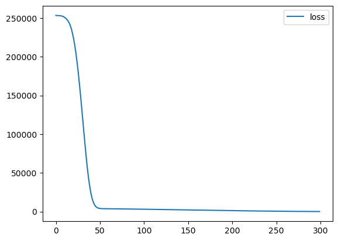

```python
loss_df.plot()
```

This is a clear proof that the `Neural Network` is `learning` from the `data` in every `epoch` and `minimizing` the `loss` `value` to make `accurate predictions`.

And you can also see that the `loss` `decreased` alot in the `first 50` `epochs` and then `decreased` `slowly` in the `next 200` `epochs`. This is normal because the `Neural Network` `learns` `quickly` in the `beginning` and then `learns` `slowly` as the `epochs` `increases` and then at certain `point` the `loss` `decreases` `very slowly` and `converges` to the `minimum` value of the `cost function`.

Now we have `trained` the `Neural Network` and `minimized` the `loss` `value` to make `accurate predictions`. We can now `test` the `Neural Network` on the `testing` `data` to `evaluate` the `performance` of the `Neural Network`.

### Evaluating the Neural Network

There are a lot of methods to evaluate the `performance` of the `Neural Network`. But the most common method is to `calculate` the `loss` `value` of the `Neural Network` on the `testing` `data`.

```python
model.evaluate(X_test, y_test, verbose=0)
```

```
104.65514373779297
```

The `evaluate` `method` is used to `evaluate` the `performance` of the `Neural Network` on the `testing` `data`. The `evaluate` `method` `returns` the `loss` `value` of the `Neural Network` on the `testing` `data` which is the `measure` of how `well` the `Neural Network` is `performing`.

This value is close to the `loss` `value` of the `Neural Network` on the `training` `data`.

```python
model.evaluate(X_train, y_train, verbose=0)
```

```
114.0151596069336
```

We can also `predict` the `price` using the `Neural Network` on the `testing` `data` to `see` how `well` the `Neural Network` is `performing`.

```python
test_predictions = model.predict(X_test)
```

```python
test_predictions[:10]
```

```
array([[629.2072 ],
       [601.0441 ],
       [326.31415],
       [502.78622],
       [462.59506],
       [505.8354 ],
       [454.12354],
       [463.57642],
       [460.74576],
       [594.16284]], dtype=float32)
```

Here you have the first `10` `predictions`.

So, now what we can do is plot the `actual price` and the `predicted price` to `visualize` how `well` the `Neural Network` is `performing`.

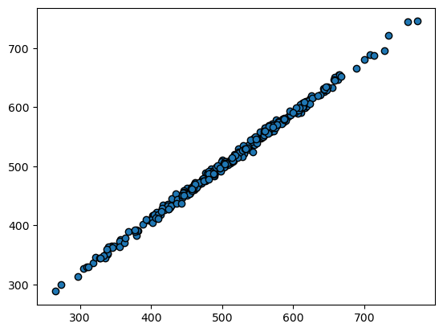

```python
import matplotlib.pyplot as plt
plt.scatter(y_test, test_predictions, edgecolors='black')
```

Notice how the `actual price` and the `predicted price` are `close` and `overlapping` each other. This is a `good` `sign` that our model is `performing` `quite well` on the `testing` `data`.

```python
from sklearn.metrics import mean_absolute_error, mean_squared_error

mean_absolute_error(y_test, test_predictions)
```

```
8.180610881134795
```

So, mean absolute error is `8.18`. Now to compare this value with the `mean price` of the `dataset` to `understand` how small or large the average margin of error is.

```python
df.describe()
```

|  | price | feature1 | feature2 |
| --- | --- | --- | --- |
| count | 1000.000000 | 1000.000000 | 1000.000000 |
| mean | 498.673029 | 1000.014171 | 999.979847 |
| std | 93.785431 | 0.974018 | 0.948330 |
| min | 223.346793 | 997.058347 | 996.995651 |
| 25% | 433.025732 | 999.332068 | 999.316106 |
| 50% | 502.382117 | 1000.009915 | 1000.002243 |
| 75% | 564.921588 | 1000.637580 | 1000.645380 |
| max | 774.407854 | 1003.207934 | 1002.666308 |

You can see the mean price is `498.67` and the mean absolute error is only `8.18`, That is pretty good I would say, taking the dataset is completely `fake`. But the `Neural Network` Somehow `learned` from the `data` and `predicted` the `price` with a `mean absolute error` of `8.18`.

There are still 2 more things I want to go through before ending the evaluation of the `Neural Network`.

We have `trained` the `Neural Network` and `evaluated` the `performance` of the `Neural Network` on the `testing` `data`. But how can we predict from the `Neural Network` on `new` `data`?

*** Predicting using new data

Suppose, you have a `new` `data` like this.

```python
new_gem = [[998, 1000]]
```

Do you remember the steps we took to `make the model` and `train` the `Neural Network`? We have to `normalize` the `new` `data` using the `MinMaxScaler` `object` that we `fitted` to the `training` `data`.

Luckily we have the `fitted` `MinMaxScaler` `object` that we `fitted` to the `training` `data`. We can `transform` the `new` `data` using the `transform` `method`.

```python
new_gem = scaler.transform(new_gem)
new_gem
```

```
array([[0.16645635, 0.52980619]])
```

We have transformed the new_data. Now I can just simply predict.

```python
model.predict(new_gem)
```

```
array([[426.16595]], dtype=float32)
```

Now Finally if you are making a very complex model and you want to `save` the `model` to `use` it later. You can `save` the `model` using the `save` `method` of the `model` `object`.

> The `model` is `saved` in the `current` `working` `directory` with the extension `.h5` meaning it's a `hdf5` `file`.

```python
model.save('my_gem_model.h5')
```

Now you can load the `model` using the `load_model` `function` from the `keras.models` `module` of the `tensorflow` `library` and use it to `predict` the `price` of the `new` `data` without going through all the `training` `process` again.

```python
from tensorflow.keras.models import load_model
```

```python
new_gem_model = load_model('my_gem_model.h5')
```

```python
new_gem_model.predict(new_gem)
```

```
array([[426.16595]], dtype=float32)
```

AAAAANNNND, Voila. We have `successfully` `built` and `trained` Our fist `Neural Network` in `Python` using the `TensorFlow` and `Keras` `libraries`.

# Conclusion

I have tried to cover all the `basics` of the `Neural Network` in this `article`. I have given more `importance` to the `theory` of the `Neural Network` because I believe that `understanding` the `theory` is very `important` to `build` and `train` the `Neural Network`.

As everything related to the algorithms and calculations are `pre-built` in the `Keras` `API` of the `TensorFlow` `library`, we just have to `import` the `classes` and `methods` and `use` them to `build` and `train` the `Neural Network`. This can take away our `headache` of `writing` the `algorithms` and `calculations` from `scratch` but it can also take away our `understanding` of the `Neural Network`.

I couldn't complete this `article` completely because it was getting too long and I didn't want to `bore` you with the `details` of the `Neural Network`. But I wanted to add a project where we use real data to make a regression model. But I will do that in the next `article`.

I know I have lacked in the `visual` `representation` of the `theory` but I have given you the links of the `videos` that can help you `understand` the `theory` of the `Neural Network` in a `better` and `easy` way.

I hope you liked the `article` and `learned` something new and `interesting` and this article will help you in your journey to become a `Data Scientist` or a `Machine Learning Engineer` or an `AI Engineer`. If you have any `questions` or `feedback`, feel free to `comment` below.